# Intercept, heritability, lambda

The liability scale follows a standard linear model

$$l_i = \beta_0 + \beta_1 g_{1,i} + \beta_2 g_{2,i} + e_i$$
This is transformed to the expected data scale

$$\nu_i = g^{-1}(l_i)$$
where the function $g()$ is the link function, which in the Poisson case is the natural $log$. Therefore, the expected data scale will be the exponential transformation of the liability.

Finally, the actual number of counts is a random sample drawn with

$$z_i = D(\nu_i)$$

Create 1000 genotypes for 10000 individuals

```r
library(dplyr)
nid <- 10000
nsnp <- 1000
af <- runif(nsnp)
h2 <- 0.8
g <- lapply(1:nsnp, function(x) rbinom(nid, 2, af[x])) %>% do.call(cbind, .)
```

Generate true effect sizes for a trait with some known heritability

```r
sigmag <- sqrt(2 * af * (1-af))
b <- rnorm(nsnp, mean=0, sd=sigmag)
```

$$\mu_l = ln \left (\frac{\mu_\nu^2}{\sqrt{\mu_\nu^2+\sigma_\nu^2}} \right ) - \sum^M 2p_j\beta_j$$
and

$$\sigma^2_l = ln \left ( 1 + \frac{\sigma^2_\nu}{\mu^2_\nu} \right )$$

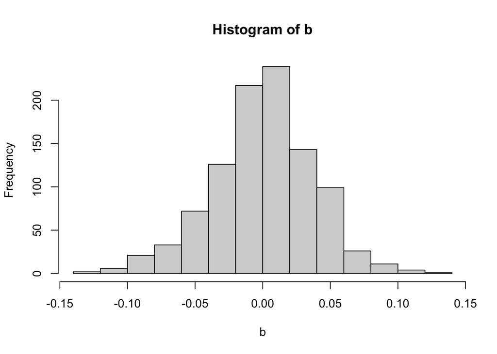

```r
sigmal <- sqrt(log(1+2^2/2^2))

vg <- sum(af * 2 * (1 - af) * b^2)
ve <- (vg - h2 * vg)/h2
vy <- vg + ve
b <- b/sqrt(vy) * sigmal
hist(b)
```

```r
sd(b)
```

```
## [1] 0.03742696
```

```r
mu <- log(2^2 / sqrt(2^2 + 2^2)) - sum(2*af*b)
```

Generate liability

```r
gbv <- g %*% b
l <- mu + gbv + rnorm(nid, 0, sqrt(sigmal^2 * (1-h2)))
cor(gbv, l)^2
```

```
##           [,1]
## [1,] 0.8000013
```

```r
nu <- exp(l)
mean(nu)
```

```
## [1] 2.027862
```

```r
sd(nu)
```

```
## [1] 1.994783
```

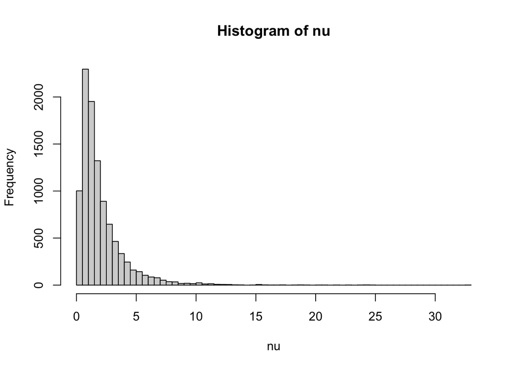

```r
hist(nu, breaks=100)
```

Transform to observed distribution

Sample counts

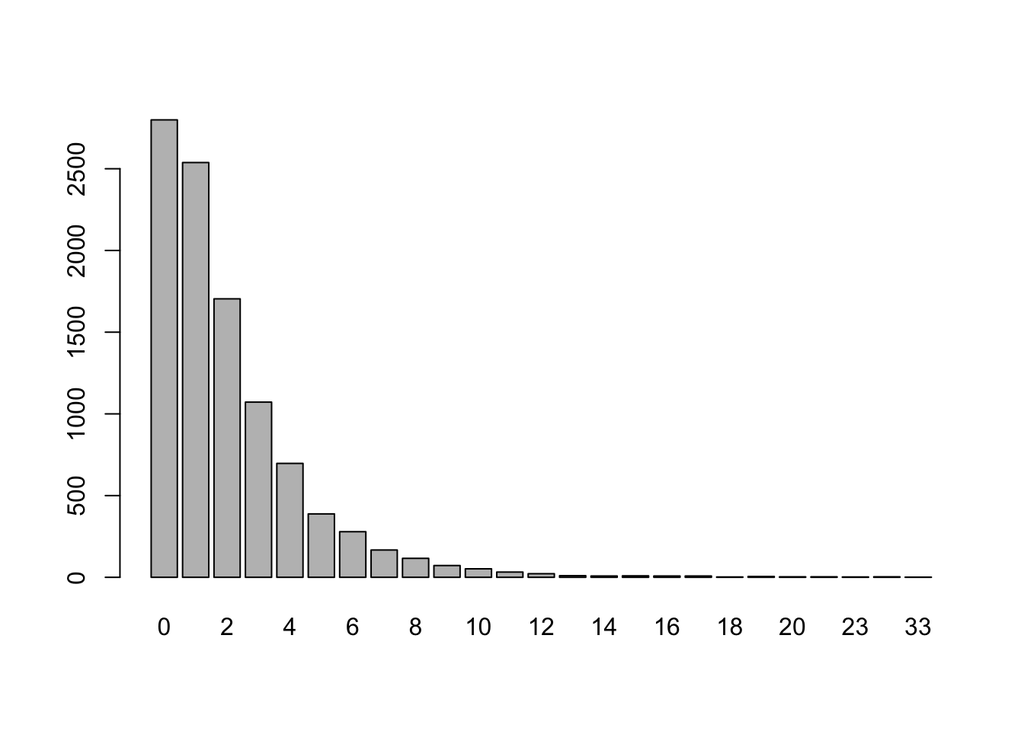

```r
y <- rpois(nid, nu)
barplot(table(y))
```

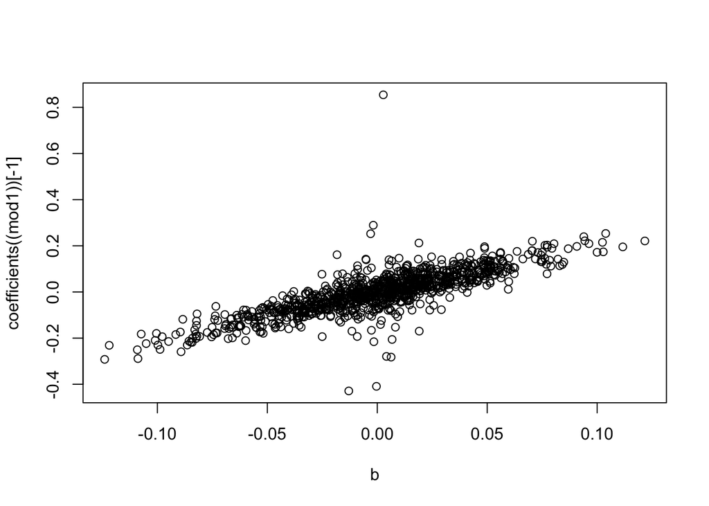

```r
mod1 <- lm(y ~ g)
mod2 <- lm(l ~ g)
plot(coefficients((mod1))[-1] ~ b)
```

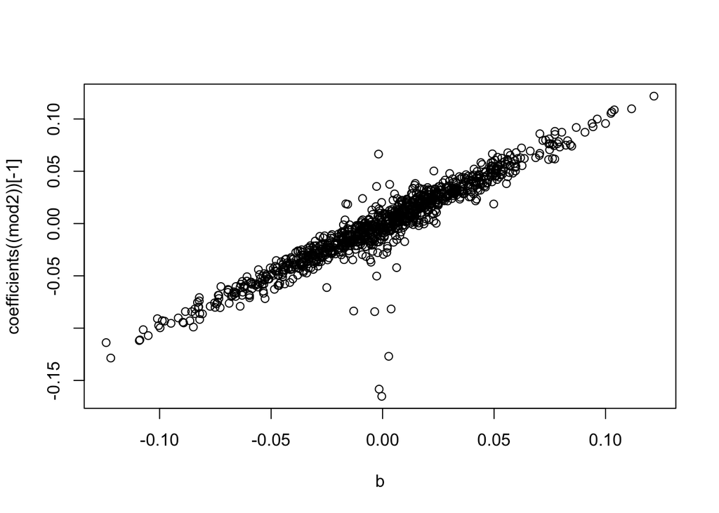

```r
plot(coefficients((mod2))[-1] ~ b)
```

```r
summary(lm(coefficients(mod1)[-1] ~ b))
```

```
##
## Call:
## lm(formula = coefficients(mod1)[-1] ~ b)
##
## Residuals:
##      Min       1Q   Median       3Q      Max
## -0.40633 -0.02548  0.00102  0.02716  0.85045
##
## Coefficients:
##              Estimate Std. Error t value Pr(>|t|)
## (Intercept) -0.001847   0.001844  -1.002    0.317
## b            2.041119   0.049269  41.428   <2e-16 ***
## ---
## Signif. codes:  0 '***' 0.001 '**' 0.01 '*' 0.05 '.' 0.1 ' ' 1
##
## Residual standard error: 0.05828 on 997 degrees of freedom
##   (1 observation deleted due to missingness)
## Multiple R-squared:  0.6325, Adjusted R-squared:  0.6322
## F-statistic:  1716 on 1 and 997 DF,  p-value: < 2.2e-16
```

```r
simulate <- function(h2, nsnp, nid, nkids)
{
  af <- runif(nsnp)
  g <- lapply(1:nsnp, function(x) rbinom(nid, 2, af[x])) %>% do.call(cbind, .)
  sigmag <- sqrt(2 * af * (1-af))
  b <- rnorm(nsnp, mean=0, sd=sigmag)
  vg <- sum(af * 2 * (1 - af) * b^2)
  ve <- (vg - h2 * vg)/h2
  vy <- vg + ve
  b <- b/sqrt(vy) * sigmal
  mu <- log(nkids^2 / sqrt(nkids^2 + nkids^2)) - sum(2*af*b)
  sigmal <- sqrt(log(1+nkids^2/nkids^2))
  gbv <- g %*% b
  l <- mu + gbv + rnorm(nid, 0, sqrt(sigmal^2 * (1-h2)))
  nu <- exp(l)
  y <- rpois(nid, nu)
  mod <- sapply(1:nsnp, function(x) lm(y ~ g[,x])$coef[2])
  return(lm(mod ~ b)$coef[2])
}

param <- expand.grid(
  h2=c(0.1, 0.3, 0.5, 0.7, 0.9),
  nkids=c(2,3),
  nsnp=c(500),
  sim=c(1:3),
  nid=10000
)

for(i in 1:nrow(param))
{
  message(i)
  param$coef[i] <- simulate(param$h2[i], param$nsnp[i], param$nid[i], param$nkids[i])
}
```

```
## 1
```

```
## 2
```

```
## 3
```

```
## 4
```

```
## 5
```

```
## 6
```

```
## 7
```

```
## 8
```

```
## 9
```

```
## 10
```

```
## 11
```

```
## 12
```

```
## 13
```

```
## 14
```

```
## 15
```

```
## 16
```

```
## 17
```

```
## 18
```

```
## 19
```

```
## 20
```

```
## 21
```

```
## 22
```

```
## 23
```

```
## 24
```

```
## 25
```

```
## 26
```

```
## 27
```

```
## 28
```

```
## 29
```

```
## 30
```

```r
str(param)
```

```
## 'data.frame':    30 obs. of  6 variables:
##  $ h2   : num  0.1 0.3 0.5 0.7 0.9 0.1 0.3 0.5 0.7 0.9 ...
##  $ nkids: num  2 2 2 2 2 3 3 3 3 3 ...
##  $ nsnp : num  500 500 500 500 500 500 500 500 500 500 ...
##  $ sim  : int  1 1 1 1 1 1 1 1 1 1 ...
##  $ nid  : num  10000 10000 10000 10000 10000 10000 10000 10000 10000 10000 ...
##  $ coef : num  2.17 2.14 1.97 2.02 2.01 ...
##  - attr(*, "out.attrs")=List of 2
##   ..$ dim     : Named int [1:5] 5 2 1 3 1
##   .. ..- attr(*, "names")= chr [1:5] "h2" "nkids" "nsnp" "sim" ...
##   ..$ dimnames:List of 5
##   .. ..$ h2   : chr [1:5] "h2=0.1" "h2=0.3" "h2=0.5" "h2=0.7" ...
##   .. ..$ nkids: chr [1:2] "nkids=2" "nkids=3"
##   .. ..$ nsnp : chr "nsnp=500"
##   .. ..$ sim  : chr [1:3] "sim=1" "sim=2" "sim=3"
##   .. ..$ nid  : chr "nid=10000"
```

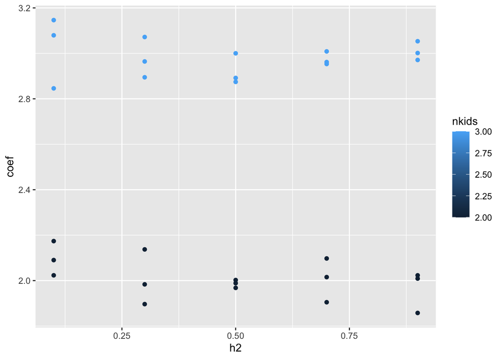

```r
library(ggplot2)
ggplot(param, aes(h2, coef)) +
  geom_point(aes(colour=nkids))
```

## Reconciling `sample` vs `rpois`

I think that once the liability is exponentiated then drawing numbers of children from the poisson, or using it as a probability in sample is going to be the same.

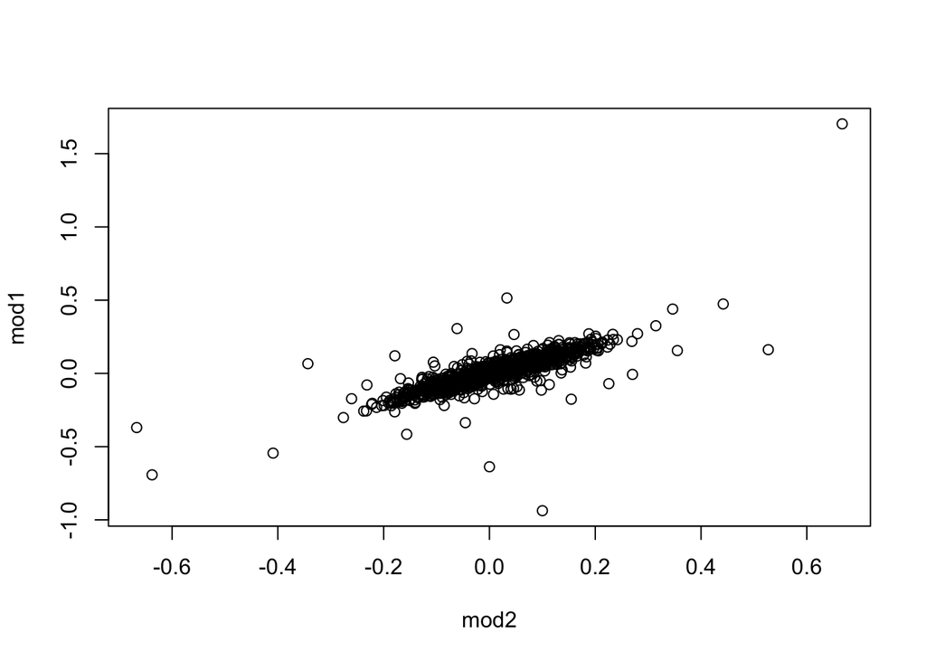

```r
nsnp <- 1000
nid <- 10000
nkids <- 2
h2 <- 0.8

# sample allele frequencies
af <- runif(nsnp)

# generate genotypes
g <- lapply(1:nsnp, function(x) rbinom(nid, 2, af[x])) %>% do.call(cbind, .)

# variance of liability should scale to nkids once exponentiated
sigmal <- sqrt(log(1+nkids^2/nkids^2))

# generate effect sizes
sigmag <- sqrt(2 * af * (1-af))
b <- rnorm(nsnp, mean=0, sd=sigmag)
vg <- sum(af * 2 * (1 - af) * b^2)
ve <- (vg - h2 * vg)/h2
vy <- vg + ve
b <- b/sqrt(vy) * sigmal

# mean of liability should scale to nkids once exponentiated
mu <- log(nkids^2 / sqrt(nkids^2 + nkids^2)) - sum(2*af*b)

# generate liability (fitness)
gbv <- g %*% b
l <- mu + gbv + rnorm(nid, 0, sqrt(sigmal^2 * (1-h2)))

# transform to observed scale
nu <- exp(l)

# sample counts by drawing from poisson
y1 <- rpois(nid, nu)

# sample counts by assigning children using sample
child_parent <- sample(1:nid, nkids*nid, replace=TRUE, prob=nu)
y2 <- rep(0,nid)
tabParents <- table(child_parent)
y2[as.numeric(unlist(dimnames(tabParents)))] <- tabParents

# estimate effects of each SNP on poisson y
mod1 <- sapply(1:nsnp, function(x) lm(y1 ~ g[,x])$coef[2])

# estimate effects of each SNP on sample y
mod2 <- sapply(1:nsnp, function(x) lm(y2 ~ g[,x])$coef[2])

# how do the SNP effect estimates compare across the two models?
plot(mod1 ~ mod2)
```

The estimated effects should by proportional to the simulated effects on the liability scale, but need to be divided by the mean number of kids per person

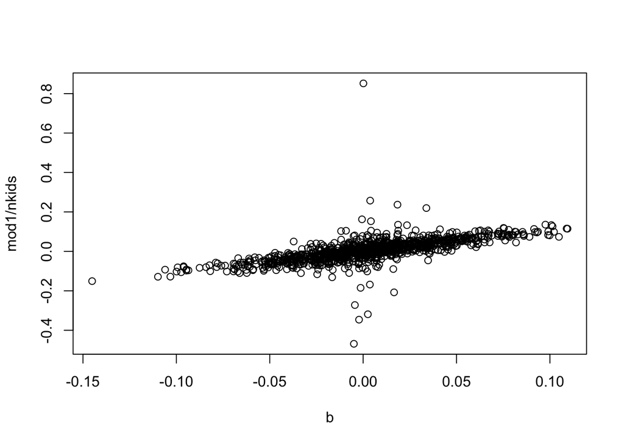

```r
plot(mod1/nkids ~ b)
```

```r
lm(mod1/nkids ~ b)
```

```
##
## Call:
## lm(formula = mod1/nkids ~ b)
##
## Coefficients:
## (Intercept)            b
##    0.001023     1.105031
```

# Compare GLM and LM

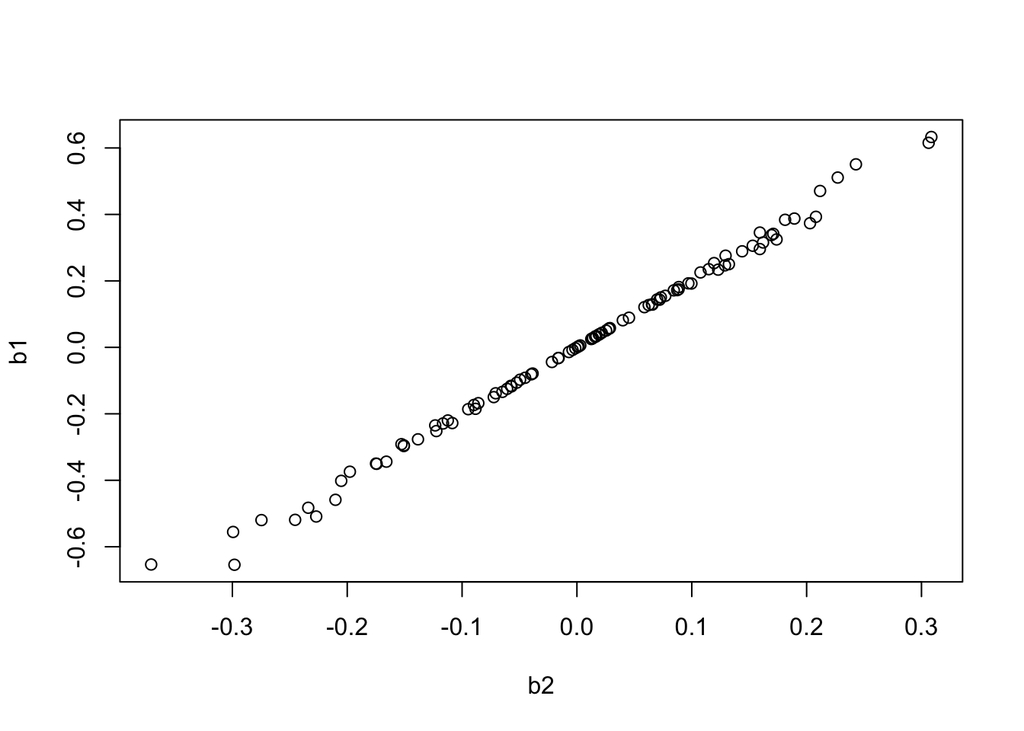

```r
nsnp <- 100
nid <- 10000
nkids <- 2
h2 <- 0.8

# sample allele frequencies
af <- runif(nsnp)

# generate genotypes
g <- lapply(1:nsnp, function(x) rbinom(nid, 2, af[x])) %>% do.call(cbind, .)

# variance of liability should scale to nkids once exponentiated
sigmal <- sqrt(log(1+nkids^2/nkids^2))

# generate effect sizes
sigmag <- sqrt(2 * af * (1-af))
b <- rnorm(nsnp, mean=0, sd=sigmag)
vg <- sum(af * 2 * (1 - af) * b^2)
ve <- (vg - h2 * vg)/h2
vy <- vg + ve
b <- b/sqrt(vy) * sigmal

# mean of liability should scale to nkids once exponentiated
mu <- log(nkids^2 / sqrt(nkids^2 + nkids^2)) - sum(2*af*b)

# generate liability (fitness)
gbv <- g %*% b
l <- mu + gbv + rnorm(nid, 0, sqrt(sigmal^2 * (1-h2)))

# transform to observed scale
nu <- exp(l)

# sample counts by drawing from poisson
y1 <- rpois(nid, nu)

# estimate effects of each SNP using lm
mod1 <- lapply(1:nsnp, function(x) summary(lm(y1 ~ g[,x])))

# estimate effects of each SNP using glm
mod2 <- lapply(1:nsnp, function(x) summary(glm(y1 ~ g[,x], family=poisson(link="log"))))

b1 <- sapply(mod1, function(x) { x$coef[2,1]})
b2 <- sapply(mod2, function(x) { x$coef[2,1]})
se1 <- sapply(mod1, function(x) { x$coef[2,2]})
se2 <- sapply(mod2, function(x) { x$coef[2,2]})
pval1 <- sapply(mod1, function(x) { x$coef[2,4]})
pval2 <- sapply(mod2, function(x) { x$coef[2,4]})

# how do the SNP effect estimates compare across the two models?
plot(b1 ~ b2)
```

```r
summary(lm(b2 ~ b1))
```

```
##
## Call:
## lm(formula = b2 ~ b1)
##
## Residuals:
##       Min        1Q    Median        3Q       Max
## -0.046623 -0.001283  0.000707  0.002402  0.026290
##
## Coefficients:
##               Estimate Std. Error t value Pr(>|t|)
## (Intercept) -0.0006918  0.0009453  -0.732    0.466
## b1           0.4949249  0.0033973 145.682   <2e-16 ***
## ---
## Signif. codes:  0 '***' 0.001 '**' 0.01 '*' 0.05 '.' 0.1 ' ' 1
##
## Residual standard error: 0.009448 on 98 degrees of freedom
## Multiple R-squared:  0.9954, Adjusted R-squared:  0.9954
## F-statistic: 2.122e+04 on 1 and 98 DF,  p-value: < 2.2e-16
```

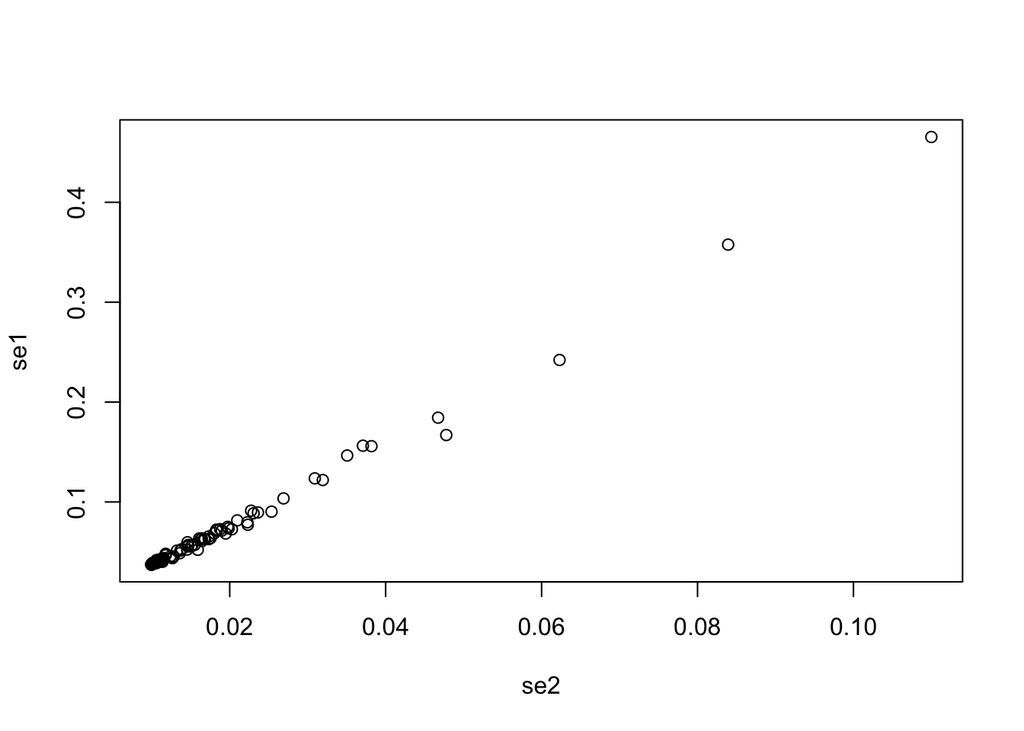

```r
plot(se1 ~ se2)
```

```r
summary(lm(se2 ~ se1))
```

```
##
## Call:
## lm(formula = se2 ~ se1)
##
## Residuals:
##        Min         1Q     Median         3Q        Max
## -0.0027889 -0.0004799 -0.0002599  0.0003361  0.0064852
##
## Coefficients:
##              Estimate Std. Error t value Pr(>|t|)
## (Intercept) 0.0014955  0.0001643   9.104 1.07e-14 ***
## se1         0.2382896  0.0018020 132.238  < 2e-16 ***
## ---
## Signif. codes:  0 '***' 0.001 '**' 0.01 '*' 0.05 '.' 0.1 ' ' 1
##
## Residual standard error: 0.001095 on 98 degrees of freedom
## Multiple R-squared:  0.9944, Adjusted R-squared:  0.9944
## F-statistic: 1.749e+04 on 1 and 98 DF,  p-value: < 2.2e-16
```

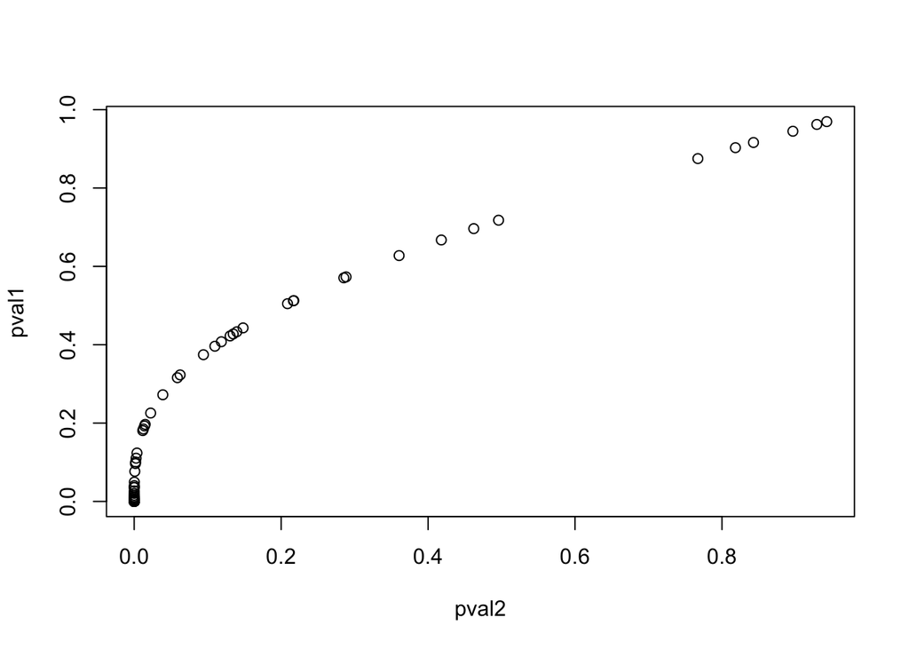

```r
plot(pval1 ~ pval2)
```

```r
table(pval1 < 0.05, pval2 < 0.05)
```

```
##
##         FALSE TRUE
##   FALSE    24   11
##   TRUE      0   65
```

- Looks like the effect estimates are extremely close - but need to divide the lm effect estimate by mean number of children in the sample
- The standard error for the lm is relatively higher - which means that it has slightly lower power

## Standard deviation units transformation

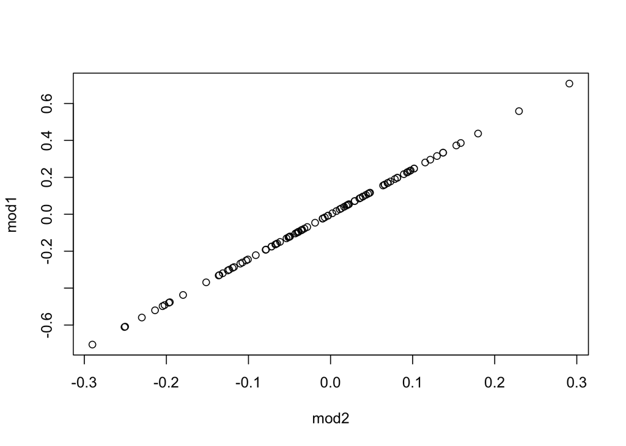

```r
nsnp <- 100
nid <- 10000
nkids <- 2
h2 <- 0.8

# sample allele frequencies
af <- runif(nsnp)

# generate genotypes
g <- lapply(1:nsnp, function(x) rbinom(nid, 2, af[x])) %>% do.call(cbind, .)

# variance of liability should scale to nkids once exponentiated
sigmal <- sqrt(log(1+nkids^2/nkids^2))

# generate effect sizes
sigmag <- sqrt(2 * af * (1-af))
b <- rnorm(nsnp, mean=0, sd=sigmag)
vg <- sum(af * 2 * (1 - af) * b^2)
ve <- (vg - h2 * vg)/h2
vy <- vg + ve
b <- b/sqrt(vy) * sigmal

# mean of liability should scale to nkids once exponentiated
mu <- log(nkids^2 / sqrt(nkids^2 + nkids^2)) - sum(2*af*b)

# generate liability (fitness)
gbv <- g %*% b
l <- mu + gbv + rnorm(nid, 0, sqrt(sigmal^2 * (1-h2)))

# transform to observed scale
nu <- exp(l)

# sample counts by drawing from poisson
y1 <- rpois(nid, nu)

# estimate effects of each SNP on raw units
mod1 <- sapply(1:nsnp, function(x) lm(y1 ~ g[,x])$coef[2])

y2 <- scale(y1)

# estimate effects of each SNP on sd units
mod2 <- sapply(1:nsnp, function(x) lm(y2 ~ g[,x])$coef[2])

# how do the SNP effect estimates compare across the two models?
plot(mod1 ~ mod2)
```

Now scale the effect estimate by sd

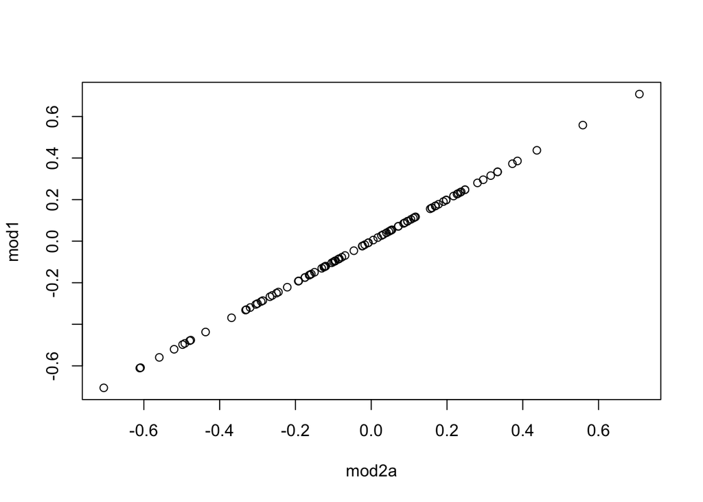

```r
mod2a <- mod2 * sd(y1)
plot(mod1 ~ mod2a)
```

## Rank Transform

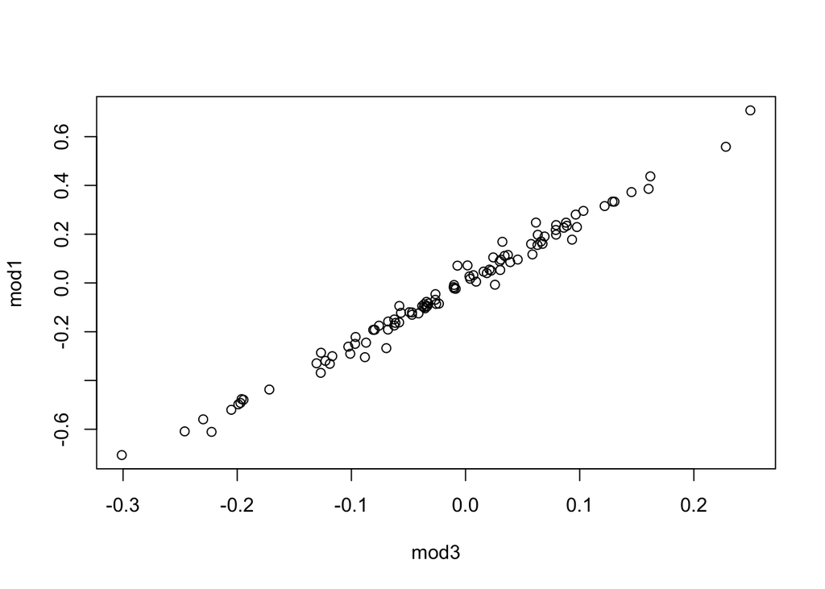

```r
library(RNOmni)
y3 <- RankNorm(y1)
mod3 <- sapply(1:nsnp, function(x) lm(y3 ~ g[,x])$coef[2])

# how do the SNP effect estimates compare across the two models?
plot(mod1 ~ mod3)
```

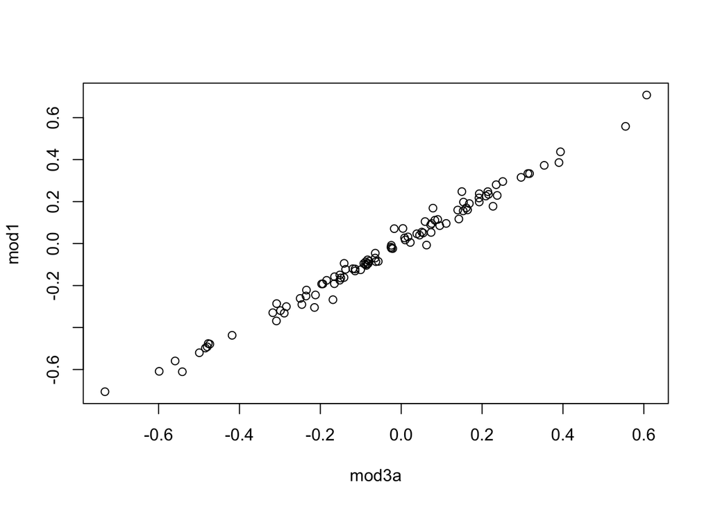

```r
mod3a <- mod3 * sd(y1)
plot(mod1 ~ mod3a)
```